# Toyota-Stanford Replication

Author: Brenden Eum (2025)

# Preamble

Things you can adjust.

```r
#rm(list=ls())
seed = 4
```

Start fresh.

```r
library(tidyverse)
library(here) # Looks for ".here" file and treats that as the root folder! Great for project management!
library(lme4)
```

```r
library(sandwich)

.root <- here()
.outdir = file.path(.root, "outputs")
.datadir = file.path(.root, "data")
.tempdir = file.path(.root, "analysis/temp")
.figdir = file.path(.root, "analysis/figures")
.tabdir = file.path(.root, "analysis/tables")
.txtdir = file.path(.root, "analysis/text")
```

Quarterly sales data from autodealerdata

```r
qs = read.csv(file.path(.datadir, "quarterly_sales_2005_2025.csv"))
```

NAcc data from Stanford - subject: subject id - Make: brand of car - Model: car model - nacc: % signal change at nacc8mm_tr4 - mpfc: % signal change at mpfc8mm_tr5, tr6, tr7 - insula_hypergranular_ana_tr4: % signal change at posterior insula, which we may use as a control for noise - knowMore_clean: ratings (1-4) how much the subjects wanted to know more - purchase_clean: ratings (1-4) subject’s purchase likelihood

```r
nacc = read.csv(file.path(.datadir, "stanford-nacc/Car2_agg_df_by_subject_run2 (1).csv"))
nacc = nacc %>%
  mutate(
    make = Make %>% tolower(),
    make = ifelse(make=="mercedes", "mercedes-benz", make),
    model = Model %>% tolower() %>% gsub(" ", "", .),
    year = 2023,
    pins = insula_hypergranular_ana_tr4
  ) %>%
  select(
    subject, year, make, model, q_slope_2023,
    nacc, mpfc, pins,
    knowMore_clean, purchase_clean
  )
```

Get all the stimuli used in the fMRI study.

```r
nacc_stim = nacc %>%
  distinct(year, make, model) %>%
  print()
```

```
##    year          make         model
## 1  2023        subaru      solterra
## 2  2023         lexus            is
## 3  2023          audi            a5
## 4  2023       hyundai        ioniq5
## 5  2023        toyota          bz4x
## 6  2023    volkswagen        tiguan
## 7  2023          ford mustangmach-e
## 8  2023           kia       stinger
## 9  2023           bmw            i4
## 10 2023         dodge       charger
## 11 2023       porsche      panamera
## 12 2023 mercedes-benz           eqs
## 13 2023        toyota  corollacross
## 14 2023        jaguar        i-pace
## 15 2023      cadillac         lyriq
## 16 2023        nissan        altima
## 17 2023         lexus            rz
## 18 2023      cadillac           xt5
## 19 2023           kia           ev6
## 20 2023         tesla        model3
## 21 2023          audi      e-trongt
## 22 2023        nissan          leaf
## 23 2023 mercedes-benz       s-class
## 24 2023           bmw       4series
## 25 2023          ford       mustang
## 26 2023    volkswagen          id.4
## 27 2023       hyundai       elantra
## 28 2023        jaguar            xf
## 29 2023       porsche        taycan
```

```r
nStim = nrow(nacc_stim)
```

# Analysis Explained

## Problem

Goodcarbadcar dataset does not distinguish different manufacturing dates for each make-model in their sales counts. Therefore, sales in 2023-Q3 could reflect both 2023 and 2024 models.

Autodealerdata dataset DOES distinguish different manufacturing dates for each make-model in their sales counts.

## Solutions

Typically, dealerships do not keep cars on a lot for more than 18 months. This means sales counts in a specific quarter will, at most, reflect the newest model and the previous year’s model.

Solution 1: Newest Model

For each stimulus, set quarterly sales equal to: - Q1: 2023-Q1 sales for 2023 model - Q2: 2023-Q2 sales for 2023 model - Q3.1: 2023-Q3 sales for 2024 model - Q4.1: 2023-Q4 sales for 2024 model

Solution 2: Oldest Model

For each stimulus, set quarterly sales equal to: - Q1: 2023-Q1 sales for 2023 model - Q2: 2023-Q2 sales for 2023 model - Q3: 2023-Q3 sales for 2023 model - Q4: 2023-Q4 sales for 2023 model

Solution 3: Both Models

For each stimulus, set quarterly sales equal to: - Q1: 2023-Q1 sales for 2023 model - Q2: 2023-Q2 sales for 2023 model - Q3: 2023-Q3 sales for 2023 model + 2023-Q3 sales for 2024 model - Q4: 2023-Q4 sales for 2023 model + 2023-Q4 sales for 2024 model

Then, use these metrics to calculate the average change in quarterly sales over the year. dQ = (1/3)[(Q2-Q1) + (Q3-Q2) + (Q4-Q3)]

### Solution 1: Newest Model

```r
df_dQ_New = data.frame()

for (s in 1:nStim) {

  make = nacc_stim$make[s]
  model = nacc_stim$model[s]

  ind1 = (qs$year==2023 & qs$make==make & qs$model==model) & (qs$year_sold==2023 & qs$quarter_sold==1)
  ind2 = (qs$year==2023 & qs$make==make & qs$model==model) & (qs$year_sold==2023 & qs$quarter_sold==2)
  ind3 = (qs$year==2024 & qs$make==make & qs$model==model) & (qs$year_sold==2023 & qs$quarter_sold==3)
  ind4 = (qs$year==2024 & qs$make==make & qs$model==model) & (qs$year_sold==2023 & qs$quarter_sold==4)

  if (sum(ind1)!=0 && sum(ind2)!=0 && sum(ind3)!=0 && sum(ind4)!=0) {

    Q1 = qs[ind1, "count"]
    Q2 = qs[ind2, "count"]
    Q3 = qs[ind3, "count"]
    Q4 = qs[ind4, "count"]

    dQ_New = (1/3)*((Q2-Q1)+(Q3-Q2)+(Q4-Q3))

    add_row = data.frame(make, model, dQ_New)
    df_dQ_New = bind_rows(df_dQ_New, add_row)

  }
}
```

### Solution 2: Oldest Model

```r
df_dQ_Old = data.frame()

for (s in 1:nStim) {

  make = nacc_stim$make[s]
  model = nacc_stim$model[s]

  ind1 = (qs$year==2023 & qs$make==make & qs$model==model) & (qs$year_sold==2023 & qs$quarter_sold==1)
  ind2 = (qs$year==2023 & qs$make==make & qs$model==model) & (qs$year_sold==2023 & qs$quarter_sold==2)
  ind3 = (qs$year==2023 & qs$make==make & qs$model==model) & (qs$year_sold==2023 & qs$quarter_sold==3)
  ind4 = (qs$year==2023 & qs$make==make & qs$model==model) & (qs$year_sold==2023 & qs$quarter_sold==4)

  if (sum(ind1)!=0 && sum(ind2)!=0 && sum(ind3)!=0 && sum(ind4)!=0) {

    Q1 = qs[ind1, "count"]
    Q2 = qs[ind2, "count"]
    Q3 = qs[ind3, "count"]
    Q4 = qs[ind4, "count"]

    dQ_Old = (1/3)*((Q2-Q1)+(Q3-Q2)+(Q4-Q3))
    Q_Old = Q1 + Q2 + Q3 + Q4

    add_row = data.frame(make, model, dQ_Old, Q_Old)
    df_dQ_Old = bind_rows(df_dQ_Old, add_row)

  }
}
```

### Solution 3: Both Models

```r
df_dQ_Both = data.frame()

for (s in 1:nStim) {

  make = nacc_stim$make[s]
  model = nacc_stim$model[s]

  ind1 = (qs$year==2023 & qs$make==make & qs$model==model) & (qs$year_sold==2023 & qs$quarter_sold==1)
  ind2 = (qs$year==2023 & qs$make==make & qs$model==model) & (qs$year_sold==2023 & qs$quarter_sold==2)
  ind3.1 = (qs$year==2023 & qs$make==make & qs$model==model) & (qs$year_sold==2023 & qs$quarter_sold==3)
  ind3.2 = (qs$year==2024 & qs$make==make & qs$model==model) & (qs$year_sold==2023 & qs$quarter_sold==3)
  ind4.1 = (qs$year==2023 & qs$make==make & qs$model==model) & (qs$year_sold==2023 & qs$quarter_sold==4)
  ind4.2 = (qs$year==2024 & qs$make==make & qs$model==model) & (qs$year_sold==2023 & qs$quarter_sold==4)

  if (sum(ind1)!=0 && sum(ind2)!=0 && sum(c(ind3.1,ind3.2))!=0 && sum(c(ind4.1,ind4.2))!=0) {

    Q1 = qs[ind1, "count"]
    Q2 = qs[ind2, "count"]
    Q3.1 =  if (sum(ind3.1)!=0) qs[ind3.1, "count"] else 0
    Q3.2 =  if (sum(ind3.2)!=0) qs[ind3.2, "count"] else 0
    Q3 = Q3.1 + Q3.2
    Q4.1 =  if (sum(ind4.1)!=0) qs[ind4.1, "count"] else 0
    Q4.2 =  if (sum(ind4.2)!=0) qs[ind4.2, "count"] else 0
    Q4 = Q4.1 + Q4.2

    dQ_Both = (1/3)*((Q2-Q1)+(Q3-Q2)+(Q4-Q3))

    add_row = data.frame(make, model, dQ_Both)
    df_dQ_Both = bind_rows(df_dQ_Both, add_row)

  }
}
```

# Replications

## Make Regression Data

```r
# Merge in autodealerdata average quarterly slopes
rdata = nacc %>%
  merge(., df_dQ_New, by=c("make", "model"), all.x=T) %>%
  merge(., df_dQ_Old, by=c("make", "model"), all.x=T) %>%
  merge(., df_dQ_Both, by=c("make", "model"), all.x=T)
```

## Check corr between datasets

goodcarbadcar data vs autodealer data.

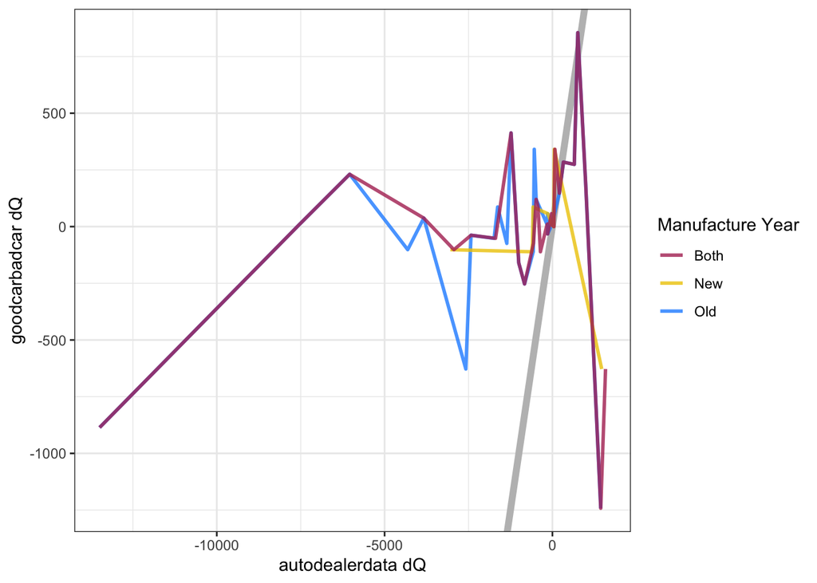

```r
corrdata = rdata %>% distinct(make, model, .keep_all=T)
ggplot(data=corrdata, aes(y=q_slope_2023)) +
  geom_abline(intercept=0, slope=1, color="grey", linewidth=2) +

  geom_line(aes(x=dQ_Old, color="Old"), linewidth=1, alpha=.8) +
  geom_line(aes(x=dQ_New, color="New"), linewidth=1, alpha=.8) +
  geom_line(aes(x=dQ_Both, color="Both"), linewidth=1, alpha=.8) +

  labs(
    y = "goodcarbadcar dQ",
    x = "autodealerdata dQ"
  ) +
  theme_bw() +
  scale_color_manual(
    name="Manufacture Year",
    values=c("Old"="dodgerblue", "New"="gold2", "Both"="maroon")
  )
```

```r
lm(q_slope_2023 ~ dQ_Old, data = corrdata) %>% summary()
```

```
##
## Call:
## lm(formula = q_slope_2023 ~ dQ_Old, data = corrdata)
##
## Residuals:
##      Min       1Q   Median       3Q      Max
## -1352.14   -70.81    11.82   158.01   773.13
##
## Coefficients:
##             Estimate Std. Error t value Pr(>|t|)
## (Intercept) 50.77723   81.04344   0.627   0.5364
## dQ_Old       0.04135    0.02335   1.771   0.0884 .
## ---
## Signif. codes:  0 '***' 0.001 '**' 0.01 '*' 0.05 '.' 0.1 ' ' 1
##
## Residual standard error: 377.9 on 26 degrees of freedom
##   (1 observation deleted due to missingness)
## Multiple R-squared:  0.1076, Adjusted R-squared:  0.07328
## F-statistic: 3.135 on 1 and 26 DF,  p-value: 0.08835
```

```r
cor.test(corrdata$q_slope_2023, corrdata$dQ_Old)
```

```
##
##  Pearson's product-moment correlation
##
## data:  corrdata$q_slope_2023 and corrdata$dQ_Old
## t = 1.7706, df = 26, p-value = 0.08835
## alternative hypothesis: true correlation is not equal to 0
## 95 percent confidence interval:
##  -0.05132691  0.62466168
## sample estimates:
##       cor
## 0.3280315
```

## Replication 1: Newest

```r
# replication_1 <- lmer(
#   dQ_New ~ 1 + nacc + (1 + nacc | subject),
#   data = rdata
# )
#
# summary(replication_1)
```

## Replication 2: Oldest

Anova analysis suggests that linear model (replication_2.2) is performing better than random effects model (replication_2.1).

```r
replication_2.1 <- lmer(
  dQ_Old ~ 1 + nacc + pins + (1 + nacc + pins | subject),
  data = rdata,
  control = lmerControl(optimizer = "bobyqa")
)
```

```
## boundary (singular) fit: see help('isSingular')
```

```r
replication_2.2 <- lm(
  dQ_Old ~ 1 + nacc + pins,
  data = rdata
)

anova(replication_2.1, replication_2.2)
```

```
## refitting model(s) with ML (instead of REML)
```

|  | npar | AIC | BIC | logLik | -2*log(L) | Chisq | Df | Pr(>Chisq) |
| --- | --- | --- | --- | --- | --- | --- | --- | --- |
| replication_2.2 | 4 | 40931.38 | 40954.10 | -20461.69 | 40923.38 | NA | NA | NA |
| replication_2.1 | 10 | 40942.33 | 40999.14 | -20461.17 | 40922.33 | 1.042373 | 6 | 0.9839549 |

```r
summary(replication_2.2)
```

```
##
## Call:
## lm(formula = dQ_Old ~ 1 + nacc + pins, data = rdata)
##
## Residuals:
##      Min       1Q   Median       3Q      Max
## -12131.4   -528.4   1075.9   1655.2   3409.0
##
## Coefficients:
##             Estimate Std. Error t value Pr(>|t|)
## (Intercept) -1655.45      66.12 -25.039   <2e-16 ***
## nacc          370.82     202.93   1.827   0.0678 .
## pins          -24.72     174.76  -0.141   0.8875
## ---
## Signif. codes:  0 '***' 0.001 '**' 0.01 '*' 0.05 '.' 0.1 ' ' 1
##
## Residual standard error: 3067 on 2163 degrees of freedom
##   (84 observations deleted due to missingness)
## Multiple R-squared:  0.001543,   Adjusted R-squared:  0.0006202
## F-statistic: 1.672 on 2 and 2163 DF,  p-value: 0.1882
```

## Replication 3: Both

Anova analysis suggests that linear model (replication_3.2) is performing better than random effects model (replication_3.1).

```r
replication_3.1 <- lmer(
  dQ_Both ~ 1 + nacc + pins + (1 + nacc + pins | subject),
  data = rdata,
  control = lmerControl(optimizer = "bobyqa")
)
```

```
## boundary (singular) fit: see help('isSingular')
```

```r
replication_3.2 <- lm(
  dQ_Both ~ 1 + nacc + pins,
  data = rdata
)

anova(replication_3.1, replication_3.2)
```

```
## refitting model(s) with ML (instead of REML)
```

|  | npar | AIC | BIC | logLik | -2*log(L) | Chisq | Df | Pr(>Chisq) |
| --- | --- | --- | --- | --- | --- | --- | --- | --- |
| replication_3.2 | 4 | 40989.70 | 41012.42 | -20490.85 | 40981.70 | NA | NA | NA |
| replication_3.1 | 10 | 41001.56 | 41058.37 | -20490.78 | 40981.56 | 0.1430477 | 6 | 0.9999422 |

Linear model results suggest NAcc is correlated with average change in quarterly sales at the 86.4% confidence level.

```r
summary(replication_3.2)
```

```
##
## Call:
## lm(formula = dQ_Both ~ 1 + nacc + pins, data = rdata)
##
## Residuals:
##      Min       1Q   Median       3Q      Max
## -12415.0   -160.3   1061.0   1523.6   3140.4
##
## Coefficients:
##             Estimate Std. Error t value Pr(>|t|)
## (Intercept) -1343.61      67.01 -20.050   <2e-16 ***
## nacc          306.82     205.68   1.492    0.136
## pins           13.81     177.13   0.078    0.938
## ---
## Signif. codes:  0 '***' 0.001 '**' 0.01 '*' 0.05 '.' 0.1 ' ' 1
##
## Residual standard error: 3109 on 2163 degrees of freedom
##   (84 observations deleted due to missingness)
## Multiple R-squared:  0.001057,   Adjusted R-squared:  0.0001329
## F-statistic: 1.144 on 2 and 2163 DF,  p-value: 0.3188
```

# Extra

## Raw yearly sales

```r
lm(Q_Old ~ 1 + nacc + pins, data=rdata) %>% summary()
```

```
##
## Call:
## lm(formula = Q_Old ~ 1 + nacc + pins, data = rdata)
##
## Residuals:
##    Min     1Q Median     3Q    Max
## -31570 -23199 -14314   9732 120893
##
## Coefficients:
##             Estimate Std. Error t value Pr(>|t|)
## (Intercept)  28799.1      745.9  38.607   <2e-16 ***
## nacc         -2757.3     2289.6  -1.204    0.229
## pins          2833.4     1971.7   1.437    0.151
## ---
## Signif. codes:  0 '***' 0.001 '**' 0.01 '*' 0.05 '.' 0.1 ' ' 1
##
## Residual standard error: 34610 on 2163 degrees of freedom
##   (84 observations deleted due to missingness)
## Multiple R-squared:  0.001459,   Adjusted R-squared:  0.0005362
## F-statistic: 1.581 on 2 and 2163 DF,  p-value: 0.2061
```